# Requirements.txt

En la clase anterior vimos como empezar a utilizar los ambientes virtuales que ya trae Python. Sin embargo hay una forma de hacerlo de manera optima mediante un archivo.

Este archivo es uno que gestiona todas las dependencias y en que versiones se necesitan las dependencias, pero este sustituye a los comandos haciéndolo más eficiente y automatizado.

Ese archivo se conoce como `requirements.txt`.

## Manos a la obra

Vayamos a la terminal y enlistemos los archivos que poseemos.

[figure not shown]

Tenemos los 3 proyectos pero hay que centrarnos primero en el de **app**. Corramos:

```
#Entrar al directorio
cd app
#activemos el entorno
source env/bin/activate
#verifiquemos que dependencias hay
pip3 freeze
```

[figure not shown]

¿Qué pasa si alguien de nuestro equipo quiere contribuir en el proyecto? Entonces el quiere instalar las mismas dependencias .

Existe el proceso manual de instalar las librerías una por una, pero lo que nosotros necesitamos para agilizar es automatizarlo con un archivo.

### Generar el archivo.txt

```
#Generar el archivo de texto con las dependencias
pip3 freeze > requirements.txt
#ver el contenido del archivo
cat requirements.txt
```

[figure not shown]

Al final es un listado del proyecto o entorno con el que estamos trabajando.

### ¿Para qué nos va a servir?

Nos va a servir para poder instalar dependencias que hay en el archivo con un solo comando y contribuir al flujo de trabajo rápido y automatizado.

Así no tenemos que instalar las dependencias de manera manual.

```
pip3 install -r requirements.txt
```

Ahora con el comando y el archivo que generamos, el gestor instalara todo lo que está ahí.

Ahora vamos a indicarles como contribuir al proyecto con el archivo requirements.txt, pondremos las instrucciones en el README.md.

### Contribuyendo en el repositorio

Para poder contribuir o desplegar la app que hemos desarrollado, deberíamos estar en una cuenta diferente de Git Hub, sigamos los pasos:

1. Hacer un fork del repositorio, para tenerlo en nuestra cuenta.

[figure not shown]

Hay que fijarnos que es un fork del repositorio original, es decir vamos a trabajar sobre una copia de los archivos del proyecto, porque será en nuestro repositorio.

2. Hacer un clone a nuestra computadora local

[figure not shown]

Ahora voy a la terminal y ejecuto las siguientes lineas:

```
#clonar repositorio
git clone https://github.com/username/repo.git
#entrar en el repositorio
cd python_pip
```

Luego procedo a leer el archivo README.md

```
#Desplegar app
#Entrar a la carpeta app
cd app
#activar el entorno
source env-app/bin/activate
#Instalar dependencias
pip3 install -r requirements.txt
#Ejecutar el archivo principal
python3 main.py
```

Cuando lo ejecuto me manda este error, porque los entornos virtuales no se mandan o guardan en github.

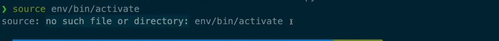

¿Qué tengo que hacer? tengo que crear mi entorno virtual con base al archivo requirements.txt. Por eso necesito correr la siguiente linea

```
#Creando el entorno virtual
python3 -m venv env-app
```

**OJO;** hay que incluir el paso anterior a la documentación para poder desplegar el entorno.

Ahora si activemos el entorno virtual y corramos todos los comandos:

```
#activar el entorno
source env-app/bin/activate
#Instalar dependencias
pip3 install -r requirements.txt
#Ejecutar el archivo principal
python3 main.py
```

Desplegando la aplicación debe arrojar algo similar a

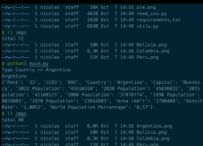

Así que modifiquemos el **README.md** para añadir el paso de crear el ambiente virtual y también solicitar un pull request en el repositorio.

Procedemos a crear un commit especifico para README.md:

```
#ver cambios en el repo
git status
#Debido a que tenía cambios en el staging
#los sacaré con
git reset HEAD
#debemos estar en la carpeta py-project
cd py-project
#añadir archivos al stage
git add README.md
#commit
git commit -m "Modificación de README.md para completar despliegue de app"
#Pull
git pull origin main
#Push
git push origin head    #Toma la rama en la que estoy y la manda al repositorio remoto
```

Ahora podré solicitar el merge:

- Vayamos al repo y nos aparecerá esto (Nos dice que estamos un commit adelante del repositorio desde el que hicimos el **fork**):

[figure not shown]

- Procedemos a pulsar el enlace y solicitar un merge (pull request).

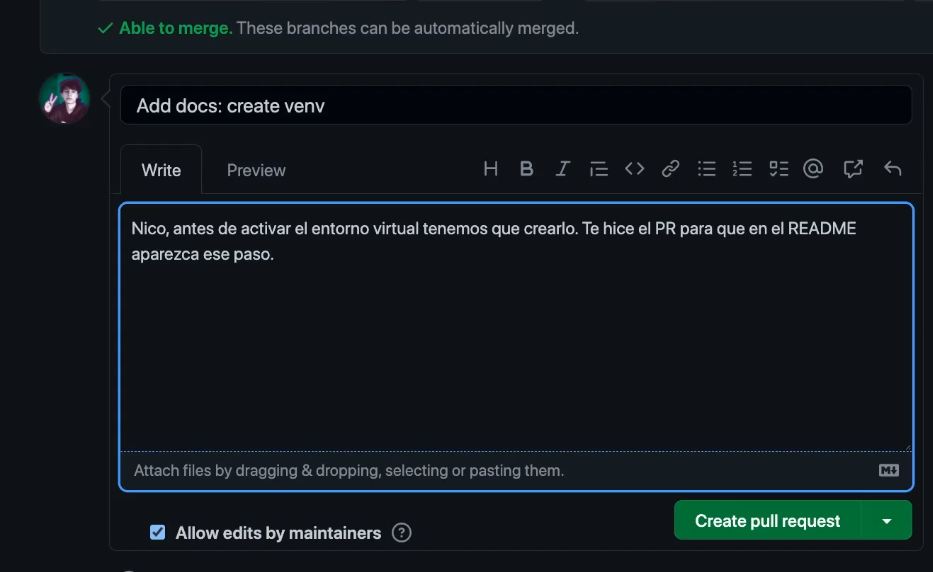

Con esto podremos solicitar el pull request. Una vez que lo solicitemos, nos va a mandar al repositorio original y en la pestaña `pull requests`, estará nuestra solicitud.

[figure not shown]

Cuando tienes permiso de poder realizar el **merge** aparecerá un botón como este, si no es el caso de que tengas acceso, no podrás ver el botón.

[figure not shown]

Y así es como se usan los archivos **requirements.txt** para poder desplegar características o dependencias de python.

Ahora procederemos a guardar todos los demás cambios con git:

```
#Añadir todos los archivos restantes al staging
git add --all
#Realizar el commit
git commit -m "Añadiendo cambios a la rama main"
#pull
git pull origin main
#push
git push origin main
```